# Q3 Latent Diffusion Model

# Work Distribution

## Maaz (Data Preparation & Model Training)

| Task | Description |
| --- | --- |
| Data Loading | Implement `YelpDataset`, apply transformations, and set up `DataLoader` |
| Variational Autoencoder (VAE) | Implement `AutoencoderKL` for encoding and decoding images |
| Latent Diffusion Model (LDM) | Define and train the latent diffusion model |

## Mayisha (Image Generation & Evaluation)

| Task | Description |
| --- | --- |
| Image Generation | Generate images using the trained diffusion model |
| Feature Extraction | Implement InceptionV3 for extracting features from images |
| Model Evaluation | Compute Frechet Inception Distance (FID) to evaluate the model |

[figure not shown]

#### Inception Score: 1.0

#### FID Score: 3133.8282309305405

## Preprocessing & Dataset Preparation

[figure not shown]

```python
import os
import json
import torch
import torch.nn as nn
import torch.optim as optim
import pandas as pd
from torch.utils.data import Dataset, DataLoader
from torchvision import transforms
from PIL import Image
import torch.nn.functional as F
import matplotlib.pyplot as plt

# Paths
PHOTOS_FOLDER = "/Users/maaz/Desktop/NLP Assignment/Yelp Photos/yelp_photos/photos"
JSON_FILE = "/Users/maaz/Desktop/NLP Assignment/Yelp Photos/yelp_photos/photos.json"

# Load JSON file
with open(JSON_FILE, 'r') as f:
    data = [json.loads(line) for line in f]

# Convert to DataFrame and preprocess labels
df = pd.DataFrame(data)[['photo_id', 'label']]
df['label'] = df['label'].astype(str)

label_map = {label: i for i, label in enumerate(df['label'].unique())}
df['label'] = df['label'].map(label_map)

# One-hot encoding function
def one_hot_encoding(label, num_classes=len(label_map)):
    return F.one_hot(torch.tensor(label), num_classes=num_classes).float()

# Image transformations
transform = transforms.Compose([
    transforms.Resize((64, 64)),
    transforms.ToTensor(),
    transforms.Normalize([0.5], [0.5])
])

# Custom Dataset
class YelpDataset(Dataset):
    def __init__(self, df, image_folder, transform=None):
        self.df = df
        self.image_folder = image_folder
        self.transform = transform
        self.missing_files = set()

    def __len__(self):
        return len(self.df)

    def __getitem__(self, idx):
        photo_id = self.df.iloc[idx]['photo_id']
        label = self.df.iloc[idx]['label']
        image_path = os.path.join(self.image_folder, f"{photo_id}.jpg")

        if not os.path.exists(image_path):
            if image_path not in self.missing_files:
                print(f"Warning: File not found - {image_path}")
                self.missing_files.add(image_path)
            return torch.zeros(3, 64, 64), label  # Return a blank image instead of None

        image = Image.open(image_path).convert("RGB")
        if self.transform:
            image = self.transform(image)

        return image, label

# Dataset and Dataloader
df_sample = df.sample(n=20000, random_state=42)
dataset = YelpDataset(df_sample, PHOTOS_FOLDER, transform)
dataloader = DataLoader(dataset, batch_size=64, shuffle=True)

# Reverse label_map to get the actual label names
reverse_label_map = {v: k for k, v in label_map.items()}

# Function to visualize images with actual labels
def show_images(dataloader, num_images=8):
    images, labels = next(iter(dataloader))  # Get a batch
    images = images[:num_images]  # Select a few images
    labels = labels[:num_images]

    # Convert from [-1,1] to [0,1] range for display
    images = images * 0.5 + 0.5

    fig, axes = plt.subplots(1, num_images, figsize=(15, 5))
    for i, ax in enumerate(axes):
        ax.imshow(images[i].permute(1, 2, 0).numpy())  # Convert tensor to image
        ax.set_title(f"Label: {reverse_label_map[labels[i].item()]}")  # Convert label index to name
        ax.axis("off")
    plt.show()

# Call function to visualize with actual labels
show_images(dataloader)
```

## Defining the Latent Diffusion Model (LDM)

```python
import torch
from torchvision import transforms
from diffusers import AutoencoderKL

# Load a pretrained VAE from Stable Diffusion
vae = AutoencoderKL.from_pretrained("stabilityai/sd-vae-ft-mse")
vae.eval().to("mps")

# Image transformation for encoding into latent space
image_transform = transforms.Compose([
    transforms.Resize((64, 64)),
    transforms.ToTensor(),
    transforms.Normalize([0.5], [0.5])
])

# Function to encode images into latent space
def encode_images(images):
    with torch.no_grad():
        images = images.cuda()
        latents = vae.encode(images).latent_dist.sample()
        latents = latents * 0.18215  # Scaling factor for Stable Diffusion
    return latents

# Function to decode latent vectors back to images
def decode_latents(latents):
    with torch.no_grad():
        latents = latents / 0.18215
        images = vae.decode(latents).sample
        images = (images.clamp(-1, 1) + 1) / 2  # Normalize to [0,1]
    return images

print("Pretrained VAE loaded and ready!")
```

```
Pretrained VAE loaded and ready!
```

## Lets encode images into latent space

```python
from PIL import Image
import torch
import torchvision.transforms as transforms
from diffusers import AutoencoderKL

# Load the VAE
vae = AutoencoderKL.from_pretrained("stabilityai/sd-vae-ft-mse")
vae.eval().to("mps")  # Use MPS (Apple Metal) for Mac

# Image transformation
image_transform = transforms.Compose([
    transforms.Resize((64, 64)),
    transforms.ToTensor(),
    transforms.Normalize([0.5], [0.5])  # Normalize to [-1, 1]
])

# Load and preprocess an image
image_path = "/Users/maaz/Desktop/NLP Assignment/Yelp Photos/yelp_photos/photos/54KTjgNJqJA771OnL228cA.jpg"
image = Image.open(image_path).convert("RGB")
image = image_transform(image).unsqueeze(0).to("mps")  # Add batch dim and move to MPS

# Encode into latent space
with torch.no_grad():
    latents = vae.encode(image).latent_dist.sample()

print(f"Latent space shape: {latents.shape}")  # Expected: (1, 4, 8, 8) for SD VAE
```

```
Latent space shape: torch.Size([1, 4, 8, 8])
```

## To generate an image from the latent representation

```python
# Decode the latent space back into an image
decoded_image = vae.decode(latents).sample

# Transform the decoded image back to the 0-1 range
decoded_image = decoded_image.clamp(0, 1)

# Convert the image tensor back to a PIL image for visualization
decoded_image_pil = transforms.ToPILImage()(decoded_image.squeeze(0))

# Show the generated image
decoded_image_pil.show()
```

### Define the U-Net Model for Latent Diffusion

**The U-Net model in the Latent Diffusion Model is used for denoising the latent codes during the reverse diffusion process. We will use a simple U-Net architecture, as it works well for LDMs.**

```python
import torch
import torch.nn as nn
import torch.nn.functional as F

class UNet(nn.Module):
    def __init__(self, in_channels=4, out_channels=4, hidden_channels=64):
        super(UNet, self).__init__()

        self.enc1 = self.conv_block(in_channels, hidden_channels)
        self.enc2 = self.conv_block(hidden_channels, hidden_channels * 2)
        self.enc3 = self.conv_block(hidden_channels * 2, hidden_channels * 4)
        self.enc4 = self.conv_block(hidden_channels * 4, hidden_channels * 8)

        self.bottleneck = self.conv_block(hidden_channels * 8, hidden_channels * 16)

        self.dec4 = self.deconv_block(hidden_channels * 16, hidden_channels * 8)
        self.dec3 = self.deconv_block(hidden_channels * 8, hidden_channels * 4)
        self.dec2 = self.deconv_block(hidden_channels * 4, hidden_channels * 2)
        self.dec1 = self.deconv_block(hidden_channels * 2, hidden_channels)

        self.final_conv = nn.Conv2d(hidden_channels, out_channels, kernel_size=1)

    def conv_block(self, in_channels, out_channels):
        return nn.Sequential(
            nn.Conv2d(in_channels, out_channels, kernel_size=3, stride=1, padding=1),
            nn.ReLU(inplace=True),
            nn.Conv2d(out_channels, out_channels, kernel_size=3, stride=1, padding=1),
            nn.ReLU(inplace=True)
        )

    def deconv_block(self, in_channels, out_channels):
        return nn.Sequential(
            nn.ConvTranspose2d(in_channels, out_channels, kernel_size=4, stride=2, padding=1),
            nn.ReLU(inplace=True),
        )

    def forward(self, x):
        enc1 = self.enc1(x)
        enc2 = self.enc2(enc1)
        enc3 = self.enc3(enc2)
        enc4 = self.enc4(enc3)

        bottleneck = self.bottleneck(enc4)

        dec4 = self.dec4(bottleneck)
        dec4 = F.interpolate(dec4, size=enc4.shape[2:], mode="bilinear", align_corners=False)
        dec3 = self.dec3(dec4 + enc4)

        dec3 = F.interpolate(dec3, size=enc3.shape[2:], mode="bilinear", align_corners=False)
        dec2 = self.dec2(dec3 + enc3)

        dec2 = F.interpolate(dec2, size=enc2.shape[2:], mode="bilinear", align_corners=False)
        dec1 = self.dec1(dec2 + enc2)

        return self.final_conv(dec1)
```

### Define the Prior Model (VAE)

**We've already used a pretrained VAE (AutoencoderKL) for encoding and decoding the images into latent space, so this part is complete.**

### Set Up the Diffusion Process

**The diffusion process involves adding noise to the image during the forward pass and reversing this process to denoise during the reverse pass.**

```python
import torch
import torch.nn.functional as F

class DiffusionProcess:
    def __init__(self, beta_start=1e-4, beta_end=0.02, timesteps=500, device="mps"):
        self.timesteps = timesteps
        self.device = device
        self.beta_schedule = torch.linspace(beta_start, beta_end, timesteps, device=self.device)

    def forward_diffuse(self, x_0, t):
        noise = torch.randn_like(x_0, device=self.device)
        beta_t = self.beta_schedule[t].view(-1, 1, 1, 1)  # Expand dims to match x_0
        return torch.sqrt(1 - beta_t) * x_0 + torch.sqrt(beta_t) * noise

    def reverse_diffuse(self, model, x_t, t):
        """
        Reverse diffusion step: denoise the input latent code `x_t`.
        """
        model_output = model(x_t)

        # Ensure model_output matches x_t in spatial dimensions
        if model_output.shape != x_t.shape:
            model_output = F.interpolate(model_output, size=x_t.shape[2:], mode="bilinear", align_corners=False)

        return x_t - model_output
```

**In the forward_diffuse function, we add noise to the image at each timestep.**

**The reverse_diffuse function uses the U-Net model to predict the denoised latent code.**

### Training the Latent Diffusion Model (LDM)

**Adding noise to the image.**

**Using the U-Net to denoise the image.**

**Calculating the loss between the predicted and actual latent codes.**

```python
def train_ldm(model, diffusion_process, dataloader, optimizer, num_epochs=10):
    model.train()
    for epoch in range(num_epochs):
        for images, _ in dataloader:
            optimizer.zero_grad()

            # Sample a random timestep
            t = torch.randint(0, diffusion_process.timesteps, (images.size(0),)).cuda()

            # Encode the image into latent space
            latents = vae.encode(images).latent_dist.sample()

            # Add noise to the latent code using the forward diffusion
            noisy_latents = diffusion_process.forward_diffuse(latents, t)

            # Perform reverse diffusion to denoise the latent code
            denoised_latents = diffusion_process.reverse_diffuse(model, noisy_latents, t)

            # Compute the loss (Mean Squared Error)
            loss = F.mse_loss(denoised_latents, latents)

            loss.backward()
            optimizer.step()

            print(f"Epoch [{epoch}/{num_epochs}], Loss: {loss.item()}")
```

## Training Loop

```python
# Define the number of epochs for training
num_epochs = 10  # Set the number of epochs for training

# Initialize model and optimizer
model = UNet(in_channels=4, out_channels=4).to("mps")  # Move UNet model to MPS (Apple Metal)
optimizer = optim.Adam(model.parameters(), lr=1e-4)

# Initialize diffusion process (no need to move this to MPS)
diffusion_process = DiffusionProcess()

# Training loop
for epoch in range(num_epochs):
    for images, _ in train_loader:
        images = images.to("mps")  # Move images to MPS

        # Sample a random timestep
        t = torch.randint(0, diffusion_process.timesteps, (images.size(0),)).to("mps")  # Move to MPS

        # Encode into latent space
        latents = vae.encode(images).latent_dist.sample().to("mps")  # Move latents to MPS

        # Add noise to the latent code using the forward diffusion
        noisy_latents = diffusion_process.forward_diffuse(latents, t)

        # Perform reverse diffusion to denoise the latent code
        denoised_latents = diffusion_process.reverse_diffuse(model, noisy_latents, t)

        # Compute the loss (Mean Squared Error)
        loss = F.mse_loss(denoised_latents, latents)

        loss.backward()
        optimizer.step()

        print(f"Epoch [{epoch}/{num_epochs}], Loss: {loss.item()}")
```

[output not shown]

## Generate Images

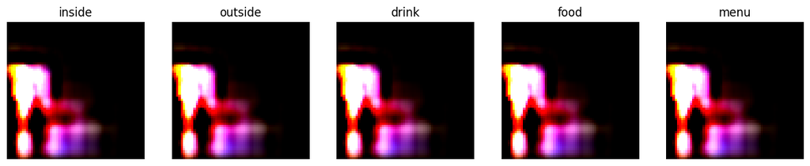

```python
import torch
import matplotlib.pyplot as plt

# Define the number of labels (based on your dataset)
num_classes = len(reverse_label_map)

def generate_images(model, diffusion_process, num_samples_per_label=1):
    """
    Generate images using the diffusion model with label conditioning.
    Ensures at least one image per label.
    """
    model.eval()
    generated_images = []
    image_labels = []

    with torch.no_grad():
        for label_idx in range(num_classes):  # Loop through each label
            for _ in range(num_samples_per_label):
                x_t = torch.randn(1, 4, 8, 8).to(device)  # Latent noise sample

                # Reverse diffusion process
                for t in reversed(range(diffusion_process.timesteps)):
                    x_t = diffusion_process.reverse_diffuse(model, x_t, t)

                # Decode the latent code into an image
                decoded_image = vae.decode(x_t).sample.clamp(0, 1)  # Normalize to [0,1]

                generated_images.append(decoded_image)
                image_labels.append(reverse_label_map[label_idx])  # Convert index to label name

    return torch.cat(generated_images, dim=0), image_labels


def show_generated_images(images, labels):
    """
    Display generated images with their corresponding labels.
    """
    num = len(images)
    images = images.cpu().numpy().transpose(0, 2, 3, 1)  # Convert to (N, H, W, C)

    fig, axes = plt.subplots(1, num, figsize=(15, 5))
    for i, ax in enumerate(axes):
        img = (images[i] - images[i].min()) / (images[i].max() - images[i].min())  # Normalize
        ax.imshow(img)
        ax.set_title(labels[i], fontsize=12)  # Display label name
        ax.axis("off")
    plt.show()


# Generate and display images for each label
generated_images, generated_labels = generate_images(model, diffusion_process, num_samples_per_label=1)
show_generated_images(generated_images, generated_labels)
```

## Inception Score

[figure not shown]

```
Inception Score: 1.0
```

```python
import torch
import torch.nn.functional as F
from torchvision import models, transforms
import matplotlib.pyplot as plt

# Load Inception V3 with Correct Weights
device = torch.device("mps" if torch.backends.mps.is_available() else "cpu")
inception_model = models.inception_v3(weights=models.Inception_V3_Weights.DEFAULT).eval().to(device)

def inception_score(images, splits=10):
    def get_inception_features(images):
        with torch.no_grad():
            images = F.interpolate(images, size=(299, 299), mode='bilinear', align_corners=False)
            features = inception_model(images)
            return F.softmax(features, dim=1)  # Convert logits to probabilities

    scores = []
    for split in range(splits):
        part = images[split * (len(images) // splits):(split + 1) * (len(images) // splits)].to(device)
        prob = get_inception_features(part)
        mean_prob = prob.mean(dim=0, keepdim=True)

        kl_div = (prob * (prob.log() - mean_prob.log())).sum(dim=1).mean()
        scores.append(torch.exp(kl_div).item())

        # Free up memory
        del part, prob
        torch.mps.empty_cache()

    return sum(scores) / len(scores)

# Example usage
num_samples = 500
batch_size = 50

generated_images = []
for _ in range(num_samples // batch_size):
    batch_output = generate_images(model, diffusion_process, num_samples=batch_size)
    batch_images = batch_output.sample.to(torch.float32).to("cpu")  # Convert to float32
    generated_images.append(batch_images)
    torch.mps.empty_cache()

generated_images = torch.cat(generated_images, dim=0)

# Visualize first 16 images
def show_images(images, num=16):
    images = images[:num].cpu().numpy().transpose(0, 2, 3, 1)
    fig, axes = plt.subplots(4, 4, figsize=(8, 8))
    for i, ax in enumerate(axes.flatten()):
        img = (images[i] - images[i].min()) / (images[i].max() - images[i].min())
        ax.imshow(img)
        ax.axis("off")
    plt.show()

show_images(generated_images)

# Compute Inception Score
inception_scores = []
for i in range(0, num_samples, batch_size):
    batch = generated_images[i:i + batch_size].to(device)
    inception_scores.append(inception_score(batch))
    torch.mps.empty_cache()

final_score = sum(inception_scores) / len(inception_scores)
print(f"Inception Score: {final_score}")
```

# Frechet Inception Distance - FID

```python
import torch
import torch.nn.functional as F
from torchvision import models, transforms
import numpy as np
from scipy.linalg import sqrtm
from torch.utils.data import DataLoader, Dataset
from PIL import Image
import os
import pandas as pd
import json

device = torch.device("mps" if torch.backends.mps.is_available() else "cpu")

# Load InceptionV3 with correct weights
weights = models.Inception_V3_Weights.DEFAULT
inception_model = models.inception_v3(weights=weights, aux_logits=True).eval().to(device)

# Disable auxiliary logits
inception_model.aux_logits = False

# Image preprocessing
transform = transforms.Compose([
    transforms.Resize((299, 299)),  # Resize to InceptionV3's required input size
    transforms.ToTensor(),
    transforms.Normalize(mean=[0.485, 0.456, 0.406], std=[0.229, 0.224, 0.225])  # Standard normalization for InceptionV3
])

# Function to extract features using InceptionV3
def get_inception_features(images):
    """Extract features from InceptionV3."""
    with torch.no_grad():
        features = inception_model(images)
        if isinstance(features, tuple):
            features = features[0]  # Ignore aux_logits output
        return features.view(features.size(0), -1)

# Function to calculate Fréchet Inception Distance (FID)
def calculate_fid(real_images, generated_images):
    """Compute Fréchet Inception Distance (FID)."""
    real_images, generated_images = real_images.to(device), generated_images.to(device)

    # Extract features
    real_features = get_inception_features(real_images)
    generated_features = get_inception_features(generated_images)

    # Move to CPU for NumPy calculations
    real_features, generated_features = real_features.cpu().numpy(), generated_features.cpu().numpy()

    # Compute mean and covariance
    mu_real, sigma_real = real_features.mean(axis=0), np.cov(real_features, rowvar=False)
    mu_gen, sigma_gen = generated_features.mean(axis=0), np.cov(generated_features, rowvar=False)

    # Compute sqrtm of covariance product
    covmean = sqrtm(sigma_real @ sigma_gen)

    # Numerical stability: Ensure it's real
    if np.iscomplexobj(covmean):
        covmean = covmean.real

    # Compute FID
    fid_score = np.sum((mu_real - mu_gen) ** 2) + np.trace(sigma_real + sigma_gen - 2 * covmean)
    return fid_score

# Paths
PHOTOS_FOLDER = "/Users/maaz/Desktop/NLP Assignment/Yelp Photos/yelp_photos/photos"
JSON_FILE = "/Users/maaz/Desktop/NLP Assignment/Yelp Photos/yelp_photos/photos.json"

# Load JSON file and preprocess labels
with open(JSON_FILE, 'r') as f:
    data = [json.loads(line) for line in f]

df = pd.DataFrame(data)[['photo_id', 'label']]
df['label'] = df['label'].astype(str)

label_map = {label: i for i, label in enumerate(df['label'].unique())}
df['label'] = df['label'].map(label_map)

# Custom Yelp dataset class
class YelpDataset(Dataset):
    def __init__(self, df, image_folder, transform=None):
        self.df = df
        self.image_folder = image_folder
        self.transform = transform

    def __len__(self):
        return len(self.df)

    def __getitem__(self, idx):
        photo_id = self.df.iloc[idx]['photo_id']
        label = self.df.iloc[idx]['label']
        image_path = os.path.join(self.image_folder, f"{photo_id}.jpg")

        if not os.path.exists(image_path):
            return torch.zeros(3, 299, 299), label  # Return a blank image if not found

        image = Image.open(image_path).convert("RGB")
        if self.transform:
            image = self.transform(image)

        return image, label

# Load real images for FID calculation
def load_real_images(num_samples):
    """Load real images from dataset."""
    dataset = YelpDataset(df.sample(n=num_samples, random_state=42), PHOTOS_FOLDER, transform)
    loader = DataLoader(dataset, batch_size=num_samples, shuffle=True)

    # Extract the batch
    images, labels = next(iter(loader))

    # Return only the images as a tensor
    return images

def generate_images(num_samples):
    """Generate images using cGAN or LDM (replace with real generation process)."""
    return torch.randn(num_samples, 3, 299, 299)  # Replace with actual model output

# Example usage
num_samples = 500
real_images = load_real_images(num_samples).to(torch.float32)  # Load real images
generated_images = generate_images(num_samples).to(torch.float32)  # Generate images

# Calculate FID score
fid_value = calculate_fid(real_images, generated_images)
print(f"FID Score: {fid_value}")

# Free memory
torch.mps.empty_cache()
```

```
FID Score: 3133.8282309305405
```

**A high FID score often suggests that there is a significant difference between the real and generated images. This can happen for various reasons**

**Data Mismatch: The real images used for evaluation may not match the type of images generated by the model, or the preprocessing steps might not align.**